# Classification and Regression

A00277360 | Fredrick J. Sigalla

18/04/2020

```r
install.packages(c("psych","gmodels", "class", "C50"), repos="http://cran.rstudio.com/", INSTALL_opts = c("--html","--no-multiarch","--no-test-load","--no-lock"))
```

## **Packages used**

On top of Base R packages, the following packages must be installed before running the script  
+ class package  
+ gmodels package  
+ dplyr package  
+ C50 package  
+ rmarkdown package  
+ psych package

## **Custom functions**

- f_z_score standardization function : - coverts numeric vector values into normal by using z-score value
- f_normalize function : - rescale numeric vectors values into normal form of 0 to 1 scale
- f_age_range function : - converts age numeric values into range of values character form
- f_num_children function : - converts numeric number of children into range of values character form

```r
f_z_score_standardization <- function(x)
{
  x_standardized <- (x - mean(x))/sd(x)
  return(x_standardized)
}

f_normalize <- function(x)
{
  x_normalized <- (x - min(x))/diff(range(x))
  return(x_normalized)
}

f_age_range <- function(x)
{
    if(x >= 1 && x <= 14){
    return("Age_Btn_1_14_Incl")
  }
  else if(x >= 15 && x <= 28){
    return("Age_Btn_15_28_Incl")
  }
  else if(x >= 29 && x <= 42){
    return("Age_Btn_29_42_Incl")
  }
  else if(x >= 43 && x <= 56){
    return("Age_Btn_43_56_Incl")
  }
}

f_num_children <- function(x)
{
  if(x >= 0 && x <= 3){
    return("C_Btn_0_3_Incl")
  }
  else if(x >= 4 && x <= 7){
    return("C_Btn_4_7_Incl")
  }
  else if(x >= 8 && x <= 11){
    return("C_Btn_8_11_Incl")
  }
  else if(x >= 12 && x <= 15){
    return("C_Btn_12_15_Incl")
  }
  else if(x >= 16){
    return("C_16_Above_Incl")
  }
}
```

## **Data sets**

The two data sets that were used for the classification and regression tasks include:

### **Contraceptive Methods Data Set**

This dataset is a subset of the 1987 National Indonesia Contraceptive Prevalence Survey. The samples are married women who were either not pregnant or do not know if they were at the time of interview. The problem is to predict the current contraceptive method choice (no use, long-term methods, or short-term methods) of a woman based on her demographic and socio-economic characteristics.

```r
cmc <- read.csv("data/cmc/cmc_data.csv", stringsAsFactors = FALSE)
str(cmc)
```

```
## 'data.frame':    1472 obs. of  10 variables:
##  $ X24 : int  45 43 42 36 19 38 21 27 45 38 ...
##  $ X2  : int  1 2 3 3 4 2 3 2 1 1 ...
##  $ X3  : int  3 3 2 3 4 3 3 3 1 3 ...
##  $ X3.1: int  10 7 9 8 0 6 1 3 8 2 ...
##  $ X1  : int  1 1 1 1 1 1 1 1 1 1 ...
##  $ X1.1: int  1 1 1 1 1 1 0 1 1 0 ...
##  $ X2.1: int  3 3 3 3 3 3 3 3 2 3 ...
##  $ X3.2: int  4 4 3 2 3 2 2 4 2 3 ...
##  $ X0  : int  0 0 0 0 0 0 0 0 1 1 ...
##  $ X1.2: int  1 1 1 1 1 1 1 1 1 1 ...
```

### **Combine Cycle Power Plant Data set**

The dataset contains 9568 data points collected from a Combined Cycle Power Plant over 6 years (2006-2011), when the power plant was set to work with full load. Features consist of hourly average ambient variables Temperature (T), Ambient Pressure (AP), Relative Humidity (RH) and Exhaust Vacuum (V) to predict the net hourly electrical energy output (EP) of the plant. A combined cycle power plant (CCPP) is composed of gas turbines (GT), steam turbines (ST) and heat recovery steam generators. In a CCPP, the electricity is generated by gas and steam turbines, which are combined in one cycle, and is transferred from one turbine to another. While the Vacuum is colected from and has effect on the Steam Turbine, the other three of the ambient variables effect the GT performance.

```r
cpp <- read.csv("data/cpp/cpp.csv", stringsAsFactors = TRUE, sep = ";")
str(cpp)
```

```
## 'data.frame':    9568 obs. of  5 variables:
##  $ AT: num  14.96 25.18 5.11 20.86 10.82 ...
##  $ V : num  41.8 63 39.4 57.3 37.5 ...
##  $ AP: num  1024 1020 1012 1010 1009 ...
##  $ RH: num  73.2 59.1 92.1 76.6 96.6 ...
##  $ PE: num  463 444 489 446 474 ...
```

## **kNN**

To start with, kNN algorithm was applied on Contraceptive data set to investigate how accurately it classifies the contraceptive method used by the woman. The target feature (the feature to be predicted) is the contraceptive method, which can be one among “No-use”, “Long-term” and “Short-term”

```r
new_variable_names <- c("Age", "Education", "Husband_Education", "Children", "Religion", "Working", "Husband_Occupation", "Std_Living", "Media_Exposure", "Contraceptive_Method")
names(cmc) <- new_variable_names
str(cmc)
```

```
## 'data.frame':    1472 obs. of  10 variables:
##  $ Age                 : int  45 43 42 36 19 38 21 27 45 38 ...
##  $ Education           : int  1 2 3 3 4 2 3 2 1 1 ...
##  $ Husband_Education   : int  3 3 2 3 4 3 3 3 1 3 ...
##  $ Children            : int  10 7 9 8 0 6 1 3 8 2 ...
##  $ Religion            : int  1 1 1 1 1 1 1 1 1 1 ...
##  $ Working             : int  1 1 1 1 1 1 0 1 1 0 ...
##  $ Husband_Occupation  : int  3 3 3 3 3 3 3 3 2 3 ...
##  $ Std_Living          : int  4 4 3 2 3 2 2 4 2 3 ...
##  $ Media_Exposure      : int  0 0 0 0 0 0 0 0 1 1 ...
##  $ Contraceptive_Method: int  1 1 1 1 1 1 1 1 1 1 ...
```

```r
cmc$Contraceptive_Method <- factor(cmc$Contraceptive_Method, levels = c(1, 2, 3), labels = c("No-use", "Long-term", "Short-term"))
str(cmc)
```

```
## 'data.frame':    1472 obs. of  10 variables:
##  $ Age                 : int  45 43 42 36 19 38 21 27 45 38 ...
##  $ Education           : int  1 2 3 3 4 2 3 2 1 1 ...
##  $ Husband_Education   : int  3 3 2 3 4 3 3 3 1 3 ...
##  $ Children            : int  10 7 9 8 0 6 1 3 8 2 ...
##  $ Religion            : int  1 1 1 1 1 1 1 1 1 1 ...
##  $ Working             : int  1 1 1 1 1 1 0 1 1 0 ...
##  $ Husband_Occupation  : int  3 3 3 3 3 3 3 3 2 3 ...
##  $ Std_Living          : int  4 4 3 2 3 2 2 4 2 3 ...
##  $ Media_Exposure      : int  0 0 0 0 0 0 0 0 1 1 ...
##  $ Contraceptive_Method: Factor w/ 3 levels "No-use","Long-term",..: 1 1 1 1 1 1 1 1 1 1 ...
```

```r
nrow(as.data.frame(complete.cases(cmc)))
```

```
## [1] 1472
```

```r
summary(cmc[-10])
```

```
##       Age          Education     Husband_Education    Children
##  Min.   :16.00   Min.   :1.000   Min.   :1.00      Min.   : 0.000
##  1st Qu.:26.00   1st Qu.:2.000   1st Qu.:3.00      1st Qu.: 1.000
##  Median :32.00   Median :3.000   Median :4.00      Median : 3.000
##  Mean   :32.54   Mean   :2.959   Mean   :3.43      Mean   : 3.262
##  3rd Qu.:39.00   3rd Qu.:4.000   3rd Qu.:4.00      3rd Qu.: 4.250
##  Max.   :49.00   Max.   :4.000   Max.   :4.00      Max.   :16.000
##     Religion         Working       Husband_Occupation   Std_Living
##  Min.   :0.0000   Min.   :0.0000   Min.   :1.000      Min.   :1.000
##  1st Qu.:1.0000   1st Qu.:0.0000   1st Qu.:1.000      1st Qu.:3.000
##  Median :1.0000   Median :1.0000   Median :2.000      Median :3.000
##  Mean   :0.8505   Mean   :0.7493   Mean   :2.138      Mean   :3.134
##  3rd Qu.:1.0000   3rd Qu.:1.0000   3rd Qu.:3.000      3rd Qu.:4.000
##  Max.   :1.0000   Max.   :1.0000   Max.   :4.000      Max.   :4.000
##  Media_Exposure
##  Min.   :0.00000
##  1st Qu.:0.00000
##  Median :0.00000
##  Mean   :0.07405
##  3rd Qu.:0.00000
##  Max.   :1.00000
```

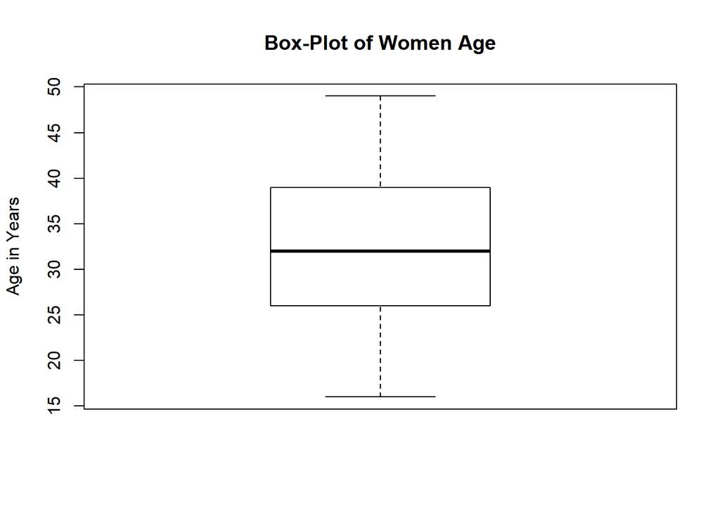

```r
boxplot(cmc$Age, main = "Box-Plot of Women Age", ylab = "Age in Years")
```

[figure not shown]

```r
boxplot(cmc$Age, main = "Box-Plot - No. Children", ylab = "Number children")
```

Summary results also showed huge variabiity of statistical valuess. For kNN to work best, all numerical values were normalize by using function f_normalize so as they all lie within 0 to 1 scale

```r
cmc_normalized <- as.data.frame(lapply(cmc[-10], f_normalize))
summary(cmc_normalized)
```

```
##       Age           Education      Husband_Education    Children
##  Min.   :0.0000   Min.   :0.0000   Min.   :0.0000    Min.   :0.0000
##  1st Qu.:0.3030   1st Qu.:0.3333   1st Qu.:0.6667    1st Qu.:0.0625
##  Median :0.4848   Median :0.6667   Median :1.0000    Median :0.1875
##  Mean   :0.5013   Mean   :0.6531   Mean   :0.8100    Mean   :0.2038
##  3rd Qu.:0.6970   3rd Qu.:1.0000   3rd Qu.:1.0000    3rd Qu.:0.2656
##  Max.   :1.0000   Max.   :1.0000   Max.   :1.0000    Max.   :1.0000
##     Religion         Working       Husband_Occupation   Std_Living
##  Min.   :0.0000   Min.   :0.0000   Min.   :0.0000     Min.   :0.0000
##  1st Qu.:1.0000   1st Qu.:0.0000   1st Qu.:0.0000     1st Qu.:0.6667
##  Median :1.0000   Median :1.0000   Median :0.3333     Median :0.6667
##  Mean   :0.8505   Mean   :0.7493   Mean   :0.3793     Mean   :0.7113
##  3rd Qu.:1.0000   3rd Qu.:1.0000   3rd Qu.:0.6667     3rd Qu.:1.0000
##  Max.   :1.0000   Max.   :1.0000   Max.   :1.0000     Max.   :1.0000
##  Media_Exposure
##  Min.   :0.00000
##  1st Qu.:0.00000
##  Median :0.00000
##  Mean   :0.07405
##  3rd Qu.:0.00000
##  Max.   :1.00000
```

```r
str(cmc_normalized)
```

```
## 'data.frame':    1472 obs. of  9 variables:
##  $ Age               : num  0.8788 0.8182 0.7879 0.6061 0.0909 ...
##  $ Education         : num  0 0.333 0.667 0.667 1 ...
##  $ Husband_Education : num  0.667 0.667 0.333 0.667 1 ...
##  $ Children          : num  0.625 0.438 0.562 0.5 0 ...
##  $ Religion          : num  1 1 1 1 1 1 1 1 1 1 ...
##  $ Working           : num  1 1 1 1 1 1 0 1 1 0 ...
##  $ Husband_Occupation: num  0.667 0.667 0.667 0.667 0.667 ...
##  $ Std_Living        : num  1 1 0.667 0.333 0.667 ...
##  $ Media_Exposure    : num  0 0 0 0 0 0 0 0 1 1 ...
```

```r
target_variable <- cmc$Contraceptive_Method
str(target_variable)
```

```
##  Factor w/ 3 levels "No-use","Long-term",..: 1 1 1 1 1 1 1 1 1 1 ...
```

```r
summary(target_variable)
```

```
##     No-use  Long-term Short-term
##        628        333        511
```

The data set was splitted into 7:3 ratio, where, 70% of the data was used as training data and 30% was used as testing data test.

```r
head(target_variable, 30)
```

```
##  [1] No-use No-use No-use No-use No-use No-use No-use No-use No-use No-use
## [11] No-use No-use No-use No-use No-use No-use No-use No-use No-use No-use
## [21] No-use No-use No-use No-use No-use No-use No-use No-use No-use No-use
## Levels: No-use Long-term Short-term
```

```r
tail(target_variable, 30)
```

```
##  [1] Short-term Short-term Short-term Short-term Short-term Short-term
##  [7] Short-term Short-term Short-term Short-term Short-term Short-term
## [13] Short-term Short-term Short-term Short-term Short-term Short-term
## [19] Short-term Short-term Short-term Short-term Short-term Short-term
## [25] Short-term Short-term Short-term Short-term Short-term Short-term
## Levels: No-use Long-term Short-term
```

```r
table(target_variable[1:1031])
```

```
##
##     No-use  Long-term Short-term
##        446        227        358
```

```r
table(target_variable[1032:1472])
```

```
##
##     No-use  Long-term Short-term
##        182        106        153
```

```r
target_variable_train <- target_variable[1:1031]
round(prop.table(table(target_variable_train)) * 100, 2)
```

```
## target_variable_train
##     No-use  Long-term Short-term
##      43.26      22.02      34.72
```

```r
target_variable_test <- target_variable[1032:1472]
round(prop.table(table(target_variable_test)) * 100, 2)
```

```
## target_variable_test
##     No-use  Long-term Short-term
##      41.27      24.04      34.69
```

```r
cmc_normalized_training <- cmc_normalized[1:1031,]
cmc_normalized_testing <- cmc_normalized[1032:1472,]
```

```r
library(class)
target_variable_pred <- knn(train = cmc_normalized_training,
                            test = cmc_normalized_testing,
                            cl = target_variable_train, k = 32)
```

Evaluating performance

```r
library(gmodels)
CrossTable(x = target_variable_test, y = target_variable_pred, prop.chisq = FALSE)
```

```
##
##
##    Cell Contents
## |-------------------------|
## |                       N |
## |           N / Row Total |
## |           N / Col Total |
## |         N / Table Total |
## |-------------------------|
##
##
## Total Observations in Table:  441
##
##
##                      | target_variable_pred
## target_variable_test |     No-use |  Long-term | Short-term |  Row Total |
## ---------------------|------------|------------|------------|------------|
##               No-use |        101 |         31 |         50 |        182 |
##                      |      0.555 |      0.170 |      0.275 |      0.413 |
##                      |      0.567 |      0.326 |      0.298 |            |
##                      |      0.229 |      0.070 |      0.113 |            |
## ---------------------|------------|------------|------------|------------|
##            Long-term |         31 |         35 |         40 |        106 |
##                      |      0.292 |      0.330 |      0.377 |      0.240 |
##                      |      0.174 |      0.368 |      0.238 |            |
##                      |      0.070 |      0.079 |      0.091 |            |
## ---------------------|------------|------------|------------|------------|
##           Short-term |         46 |         29 |         78 |        153 |
##                      |      0.301 |      0.190 |      0.510 |      0.347 |
##                      |      0.258 |      0.305 |      0.464 |            |
##                      |      0.104 |      0.066 |      0.177 |            |
## ---------------------|------------|------------|------------|------------|
##         Column Total |        178 |         95 |        168 |        441 |
##                      |      0.404 |      0.215 |      0.381 |            |
## ---------------------|------------|------------|------------|------------|
##
##
```

On implementing kNN, the value of k was 32, and this is because, the training data set had almost 1032 examples, so the value of k was obtained from the square root of the number of the examples.

The predicted vector of contraceptive method was evaluated against the actual contraceptive method to check the model’s accuracy

## **Decision Tree**

Decision Tree with a C5.0 Implementation was used to build a model to perform classification on the same data set (contraceptive methods)

```r
str(cmc)
```

```
## 'data.frame':    1472 obs. of  10 variables:
##  $ Age                 : int  45 43 42 36 19 38 21 27 45 38 ...
##  $ Education           : int  1 2 3 3 4 2 3 2 1 1 ...
##  $ Husband_Education   : int  3 3 2 3 4 3 3 3 1 3 ...
##  $ Children            : int  10 7 9 8 0 6 1 3 8 2 ...
##  $ Religion            : int  1 1 1 1 1 1 1 1 1 1 ...
##  $ Working             : int  1 1 1 1 1 1 0 1 1 0 ...
##  $ Husband_Occupation  : int  3 3 3 3 3 3 3 3 2 3 ...
##  $ Std_Living          : int  4 4 3 2 3 2 2 4 2 3 ...
##  $ Media_Exposure      : int  0 0 0 0 0 0 0 0 1 1 ...
##  $ Contraceptive_Method: Factor w/ 3 levels "No-use","Long-term",..: 1 1 1 1 1 1 1 1 1 1 ...
```

Converting numeric values of featurs Age and Number of Children into range of values in character format (Decision Tree doesnt work well with numeric values)

```r
cmc$Age <- as.character(lapply(cmc$Age, f_age_range))
cmc$Children <- as.character(lapply(cmc$Children, f_num_children))
str(cmc)
```

```
## 'data.frame':    1472 obs. of  10 variables:
##  $ Age                 : chr  "Age_Btn_43_56_Incl" "Age_Btn_43_56_Incl" "Age_Btn_29_42_Incl" "Age_Btn_29_42_Incl" ...
##  $ Education           : int  1 2 3 3 4 2 3 2 1 1 ...
##  $ Husband_Education   : int  3 3 2 3 4 3 3 3 1 3 ...
##  $ Children            : chr  "C_Btn_8_11_Incl" "C_Btn_4_7_Incl" "C_Btn_8_11_Incl" "C_Btn_8_11_Incl" ...
##  $ Religion            : int  1 1 1 1 1 1 1 1 1 1 ...
##  $ Working             : int  1 1 1 1 1 1 0 1 1 0 ...
##  $ Husband_Occupation  : int  3 3 3 3 3 3 3 3 2 3 ...
##  $ Std_Living          : int  4 4 3 2 3 2 2 4 2 3 ...
##  $ Media_Exposure      : int  0 0 0 0 0 0 0 0 1 1 ...
##  $ Contraceptive_Method: Factor w/ 3 levels "No-use","Long-term",..: 1 1 1 1 1 1 1 1 1 1 ...
```

All categorical features were also converted into factors for the same reason, Decision Tree works best with factors

```r
cmc$Education <- factor(cmc$Education, levels = c(1, 2, 3, 4), labels = c("low", "high", "high", "high"))
cmc$Husband_Education <- factor(cmc$Husband_Education, levels = c(1, 2, 3, 4), labels = c("low", "high", "high", "high"))
cmc$Religion <- factor(cmc$Religion, levels = c(0, 1), labels = c("Non-Islam", "Islam"))
cmc$Working <- factor(cmc$Working, levels = c(0, 1), labels = c("Yes", "No"))
cmc$Husband_Occupation <- factor(cmc$Husband_Occupation, levels = c(1, 2, 3, 4), labels = c("1", "2", "3", "4"))
cmc$Std_Living <- factor(cmc$Std_Living, levels = c(1, 2, 3, 4), labels = c("low", "high", "high", "high"))
cmc$Media_Exposure <- factor(cmc$Media_Exposure, levels = c(0, 1), labels = c("Good", "Not good"))
```

For decision tree, the data set was splitted in 9:1 ratio, with 90% of the data being used for training the model and the remaining 10% was used for testing the model

```r
round(prop.table(table(cmc$Contraceptive_Method)) * 100, 2)
```

```
##
##     No-use  Long-term Short-term
##      42.66      22.62      34.71
```

```r
cmc_dt_train <- cmc[1:1325,]
str(cmc_dt_train)
```

```
## 'data.frame':    1325 obs. of  10 variables:
##  $ Age                 : chr  "Age_Btn_43_56_Incl" "Age_Btn_43_56_Incl" "Age_Btn_29_42_Incl" "Age_Btn_29_42_Incl" ...
##  $ Education           : Factor w/ 2 levels "low","high": 1 2 2 2 2 2 2 2 1 1 ...
##  $ Husband_Education   : Factor w/ 2 levels "low","high": 2 2 2 2 2 2 2 2 1 2 ...
##  $ Children            : chr  "C_Btn_8_11_Incl" "C_Btn_4_7_Incl" "C_Btn_8_11_Incl" "C_Btn_8_11_Incl" ...
##  $ Religion            : Factor w/ 2 levels "Non-Islam","Islam": 2 2 2 2 2 2 2 2 2 2 ...
##  $ Working             : Factor w/ 2 levels "Yes","No": 2 2 2 2 2 2 1 2 2 1 ...
##  $ Husband_Occupation  : Factor w/ 4 levels "1","2","3","4": 3 3 3 3 3 3 3 3 2 3 ...
##  $ Std_Living          : Factor w/ 2 levels "low","high": 2 2 2 2 2 2 2 2 2 2 ...
##  $ Media_Exposure      : Factor w/ 2 levels "Good","Not good": 1 1 1 1 1 1 1 1 2 2 ...
##  $ Contraceptive_Method: Factor w/ 3 levels "No-use","Long-term",..: 1 1 1 1 1 1 1 1 1 1 ...
```

```r
cmc_dt_test <- cmc[1326:1472,]
str(cmc_dt_test)
```

```
## 'data.frame':    147 obs. of  10 variables:
##  $ Age                 : chr  "Age_Btn_29_42_Incl" "Age_Btn_29_42_Incl" "Age_Btn_15_28_Incl" "Age_Btn_29_42_Incl" ...
##  $ Education           : Factor w/ 2 levels "low","high": 2 2 2 2 2 2 1 2 2 2 ...
##  $ Husband_Education   : Factor w/ 2 levels "low","high": 2 2 2 2 2 2 2 2 2 2 ...
##  $ Children            : chr  "C_Btn_4_7_Incl" "C_Btn_4_7_Incl" "C_Btn_0_3_Incl" "C_Btn_0_3_Incl" ...
##  $ Religion            : Factor w/ 2 levels "Non-Islam","Islam": 2 2 2 2 1 2 2 2 2 2 ...
##  $ Working             : Factor w/ 2 levels "Yes","No": 1 2 2 2 2 2 2 2 1 1 ...
##  $ Husband_Occupation  : Factor w/ 4 levels "1","2","3","4": 2 3 3 3 1 3 3 1 1 3 ...
##  $ Std_Living          : Factor w/ 2 levels "low","high": 2 2 2 2 2 2 2 2 2 2 ...
##  $ Media_Exposure      : Factor w/ 2 levels "Good","Not good": 2 1 1 1 1 1 1 1 1 1 ...
##  $ Contraceptive_Method: Factor w/ 3 levels "No-use","Long-term",..: 3 3 3 3 3 3 3 3 3 3 ...
```

```r
round(prop.table(table(cmc_dt_train$Contraceptive_Method)) * 100,2)
```

```
##
##     No-use  Long-term Short-term
##      47.40      25.13      27.47
```

```r
round(prop.table(table(cmc_dt_test$Contraceptive_Method)) * 100,2)
```

```
##
##     No-use  Long-term Short-term
##          0          0        100
```

From the above operation, it was observed that, the ration of the target variable was not that fair, therefore, the data was randomised first before being splitted again into 9:1 ration, training and testing data set respectively

```r
set.seed(12345)
cmc_rand <- cmc[order(runif(1472)),]
str(cmc_rand)
```

```
## 'data.frame':    1472 obs. of  10 variables:
##  $ Age                 : chr  "Age_Btn_15_28_Incl" "Age_Btn_29_42_Incl" "Age_Btn_29_42_Incl" "Age_Btn_29_42_Incl" ...
##  $ Education           : Factor w/ 2 levels "low","high": 2 2 2 2 2 2 2 2 2 2 ...
##  $ Husband_Education   : Factor w/ 2 levels "low","high": 2 2 2 2 2 2 2 2 2 2 ...
##  $ Children            : chr  "C_Btn_0_3_Incl" "C_Btn_0_3_Incl" "C_Btn_0_3_Incl" "C_Btn_0_3_Incl" ...
##  $ Religion            : Factor w/ 2 levels "Non-Islam","Islam": 2 2 2 1 2 2 2 2 2 1 ...
##  $ Working             : Factor w/ 2 levels "Yes","No": 1 2 1 2 2 2 1 1 1 1 ...
##  $ Husband_Occupation  : Factor w/ 4 levels "1","2","3","4": 1 2 1 1 3 2 1 3 3 1 ...
##  $ Std_Living          : Factor w/ 2 levels "low","high": 2 2 2 2 2 2 2 2 1 2 ...
##  $ Media_Exposure      : Factor w/ 2 levels "Good","Not good": 1 1 1 1 1 1 1 1 1 1 ...
##  $ Contraceptive_Method: Factor w/ 3 levels "No-use","Long-term",..: 1 1 3 2 3 1 1 1 1 1 ...
```

```r
round(prop.table(table(cmc_rand$Contraceptive_Method)) * 100,2)
```

```
##
##     No-use  Long-term Short-term
##      42.66      22.62      34.71
```

```r
cmc_rand_train <- cmc_rand[1:1325,]
str(cmc_rand_train)
```

```
## 'data.frame':    1325 obs. of  10 variables:
##  $ Age                 : chr  "Age_Btn_15_28_Incl" "Age_Btn_29_42_Incl" "Age_Btn_29_42_Incl" "Age_Btn_29_42_Incl" ...
##  $ Education           : Factor w/ 2 levels "low","high": 2 2 2 2 2 2 2 2 2 2 ...
##  $ Husband_Education   : Factor w/ 2 levels "low","high": 2 2 2 2 2 2 2 2 2 2 ...
##  $ Children            : chr  "C_Btn_0_3_Incl" "C_Btn_0_3_Incl" "C_Btn_0_3_Incl" "C_Btn_0_3_Incl" ...
##  $ Religion            : Factor w/ 2 levels "Non-Islam","Islam": 2 2 2 1 2 2 2 2 2 1 ...
##  $ Working             : Factor w/ 2 levels "Yes","No": 1 2 1 2 2 2 1 1 1 1 ...
##  $ Husband_Occupation  : Factor w/ 4 levels "1","2","3","4": 1 2 1 1 3 2 1 3 3 1 ...
##  $ Std_Living          : Factor w/ 2 levels "low","high": 2 2 2 2 2 2 2 2 1 2 ...
##  $ Media_Exposure      : Factor w/ 2 levels "Good","Not good": 1 1 1 1 1 1 1 1 1 1 ...
##  $ Contraceptive_Method: Factor w/ 3 levels "No-use","Long-term",..: 1 1 3 2 3 1 1 1 1 1 ...
```

```r
cmc_rand_test <- cmc_rand[1326:1472,]
str(cmc_rand_test)
```

```
## 'data.frame':    147 obs. of  10 variables:
##  $ Age                 : chr  "Age_Btn_15_28_Incl" "Age_Btn_29_42_Incl" "Age_Btn_29_42_Incl" "Age_Btn_15_28_Incl" ...
##  $ Education           : Factor w/ 2 levels "low","high": 2 2 1 2 2 2 2 1 2 2 ...
##  $ Husband_Education   : Factor w/ 2 levels "low","high": 2 2 2 2 2 2 2 2 2 2 ...
##  $ Children            : chr  "C_Btn_0_3_Incl" "C_Btn_0_3_Incl" "C_Btn_4_7_Incl" "C_Btn_0_3_Incl" ...
##  $ Religion            : Factor w/ 2 levels "Non-Islam","Islam": 2 2 2 2 2 2 1 2 2 2 ...
##  $ Working             : Factor w/ 2 levels "Yes","No": 2 2 2 2 2 2 1 2 2 2 ...
##  $ Husband_Occupation  : Factor w/ 4 levels "1","2","3","4": 1 1 3 2 3 3 3 2 2 1 ...
##  $ Std_Living          : Factor w/ 2 levels "low","high": 1 2 2 2 2 2 2 2 2 2 ...
##  $ Media_Exposure      : Factor w/ 2 levels "Good","Not good": 1 1 1 1 1 1 1 2 1 1 ...
##  $ Contraceptive_Method: Factor w/ 3 levels "No-use","Long-term",..: 1 2 3 3 1 1 1 1 2 1 ...
```

After randomization, the split of the target variable between training and testing data set was reasonably fair

```r
round(prop.table(table(cmc_rand_test$Contraceptive_Method)) * 100, 2)
```

```
##
##     No-use  Long-term Short-term
##      45.58      19.05      35.37
```

```r
round(prop.table(table(cmc_rand_train$Contraceptive_Method)) * 100, 2)
```

```
##
##     No-use  Long-term Short-term
##      42.34      23.02      34.64
```

Using C5.0 Decision Tree Implementation to build the model

```r
library(C50)
cmc_dt_model <- C5.0(cmc_rand_train[-10], cmc_rand_train$Contraceptive_Method)
summary(cmc_dt_model)
```

```
##
## Call:
## C5.0.default(x = cmc_rand_train[-10], y = cmc_rand_train$Contraceptive_Method)
##
##
## C5.0 [Release 2.07 GPL Edition]      Tue Apr 21 23:25:35 2020
## -------------------------------
##
## Class specified by attribute `outcome'
##
## Read 1325 cases (10 attributes) from undefined.data
##
## Decision tree:
##
## Education = low: No-use (135/42)
## Education = high:
## :...Husband_Occupation = 1:
##     :...Children = C_Btn_0_3_Incl: No-use (237/138)
##     :   Children in {C_Btn_4_7_Incl,C_Btn_8_11_Incl,
##     :   :            C_Btn_12_15_Incl}: Long-term (139/75)
##     :   Children = C_16_Above_Incl: Short-term (1)
##     Husband_Occupation in {2,3,4}:
##     :...Age = Age_Btn_43_56_Incl: No-use (73/32)
##         Age = Age_Btn_15_28_Incl:
##         :...Husband_Education = low: Long-term (6/3)
##         :   Husband_Education = high:
##         :   :...Working = Yes:
##         :       :...Religion = Non-Islam: Short-term (7/3)
##         :       :   Religion = Islam: No-use (59/26)
##         :       Working = No:
##         :       :...Media_Exposure = Good: Short-term (277/142)
##         :           Media_Exposure = Not good:
##         :           :...Std_Living = low: No-use (6/1)
##         :               Std_Living = high: Short-term (5/1)
##         Age = Age_Btn_29_42_Incl:
##         :...Children in {C_Btn_12_15_Incl,
##             :            C_16_Above_Incl}: Short-term (0)
##             Children = C_Btn_8_11_Incl: No-use (26/9)
##             Children = C_Btn_0_3_Incl:
##             :...Working = Yes: No-use (69/32)
```

[output cut: 25 more lines]

```
##
##  Attribute usage:
##
##  100.00% Education
##   89.81% Husband_Occupation
##   61.36% Age
##   57.13% Children
##   40.60% Working
##   40.00% Husband_Education
##   34.19% Media_Exposure
##   16.68% Religion
##    0.83% Std_Living
##
##
## Time: 0.0 secs
```

Evaluating the model by using the testing data set

```r
cmc_dt_pred <- predict(cmc_dt_model, cmc_rand_test[-10])

CrossTable(cmc_rand_test$Contraceptive_Method, cmc_dt_pred, prop.chisq = FALSE,
           prop.c = FALSE, prop.r = FALSE, dnn = c("Actual CMC", "Predicted CMC"))
```

```
##
##
##    Cell Contents
## |-------------------------|
## |                       N |
## |         N / Table Total |
## |-------------------------|
##
##
## Total Observations in Table:  147
##
##
##              | Predicted CMC
##   Actual CMC |     No-use |  Long-term | Short-term |  Row Total |
## -------------|------------|------------|------------|------------|
##       No-use |         40 |          3 |         24 |         67 |
##              |      0.272 |      0.020 |      0.163 |            |
## -------------|------------|------------|------------|------------|
##    Long-term |          9 |          9 |         10 |         28 |
##              |      0.061 |      0.061 |      0.068 |            |
## -------------|------------|------------|------------|------------|
##   Short-term |         19 |          7 |         26 |         52 |
##              |      0.129 |      0.048 |      0.177 |            |
## -------------|------------|------------|------------|------------|
## Column Total |         68 |         19 |         60 |        147 |
## -------------|------------|------------|------------|------------|
##
##
```

## **Multiple Regression**

For multiple regress, the data set for combined cycle power plant was used, where the objective was to create a model that can predict the amount of electrical energy produced basing on othe four independent features namely ambient temperature, ambient pressure, exhaust vacuum and relative humidity.

```r
str(cpp)
```

```
## 'data.frame':    9568 obs. of  5 variables:
##  $ AT: num  14.96 25.18 5.11 20.86 10.82 ...
##  $ V : num  41.8 63 39.4 57.3 37.5 ...
##  $ AP: num  1024 1020 1012 1010 1009 ...
##  $ RH: num  73.2 59.1 92.1 76.6 96.6 ...
##  $ PE: num  463 444 489 446 474 ...
```

Data features were renamed to more intutiive names for easy interpretation

```r
features <- c("Temperature", "Vacuum", "Pressure", "Humidity", "Energy")
colnames(cpp)
```

```
## [1] "AT" "V"  "AP" "RH" "PE"
```

```r
colnames(cpp) <- features
colnames(cpp)
```

```
## [1] "Temperature" "Vacuum"      "Pressure"    "Humidity"    "Energy"
```

```r
str(cpp)
```

```
## 'data.frame':    9568 obs. of  5 variables:
##  $ Temperature: num  14.96 25.18 5.11 20.86 10.82 ...
##  $ Vacuum     : num  41.8 63 39.4 57.3 37.5 ...
##  $ Pressure   : num  1024 1020 1012 1010 1009 ...
##  $ Humidity   : num  73.2 59.1 92.1 76.6 96.6 ...
##  $ Energy     : num  463 444 489 446 474 ...
```

Data set didn’t have any missing value as shown below

```r
cpp[rowSums(is.na(cpp)) > 0, ]
```

```
## [1] Temperature Vacuum      Pressure    Humidity    Energy
## <0 rows> (or 0-length row.names)
```

Statistical summary

```r
summary(cpp)
```

```
##   Temperature        Vacuum         Pressure         Humidity
##  Min.   : 1.81   Min.   :25.36   Min.   : 992.9   Min.   : 25.56
##  1st Qu.:13.51   1st Qu.:41.74   1st Qu.:1009.1   1st Qu.: 63.33
##  Median :20.34   Median :52.08   Median :1012.9   Median : 74.97
##  Mean   :19.65   Mean   :54.31   Mean   :1013.3   Mean   : 73.31
##  3rd Qu.:25.72   3rd Qu.:66.54   3rd Qu.:1017.3   3rd Qu.: 84.83
##  Max.   :37.11   Max.   :81.56   Max.   :1033.3   Max.   :100.16
##      Energy
##  Min.   :420.3
##  1st Qu.:439.8
##  Median :451.6
##  Mean   :454.4
##  3rd Qu.:468.4
##  Max.   :495.8
```

```r
summary(cpp$Energy)
```

```
##    Min. 1st Qu.  Median    Mean 3rd Qu.    Max.
##   420.3   439.8   451.6   454.4   468.4   495.8
```

Checking for outliers as well as confirming the dependent variable is normally distributed. (Linear Regression assume the dependent variable is normally distributed)

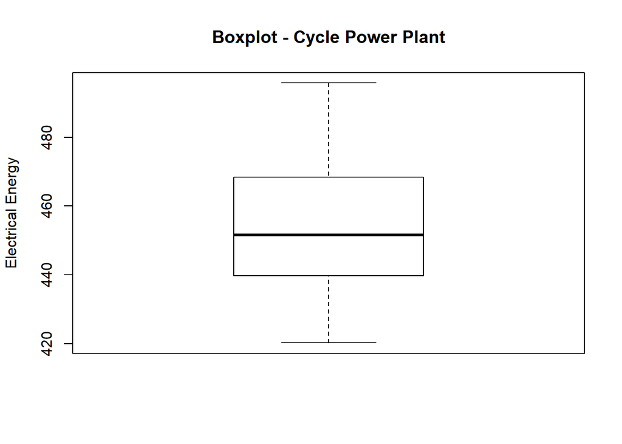

```r
boxplot(cpp$Energy, main = "Boxplot - Cycle Power Plant", ylab = "Electrical Energy")
```

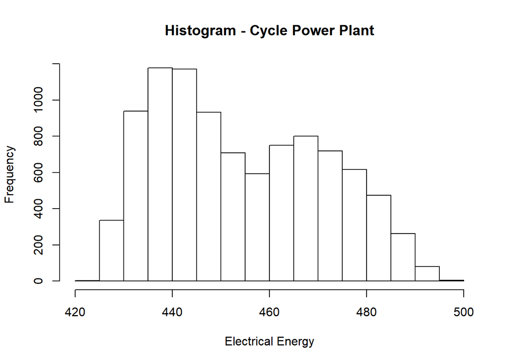

```r
hist(cpp$Energy, main = "Histogram - Cycle Power Plant", xlab = "Electrical Energy")
```

Correlation among independent variables and dependent variable was explored to see how each variable is related to one another

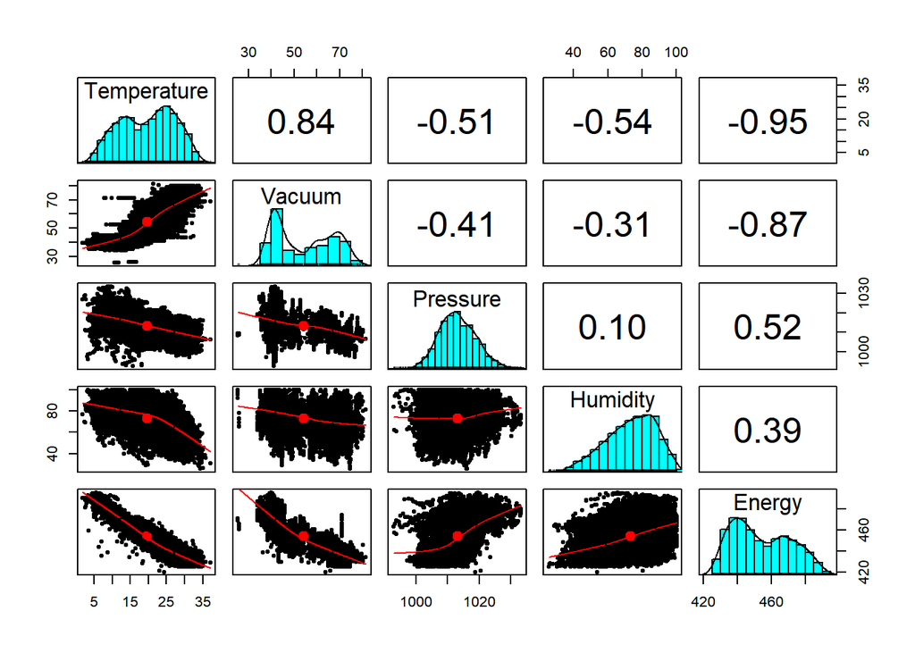

```r
library(psych)
pairs.panels(cpp[c('Temperature','Vacuum','Pressure','Humidity','Energy')])
```

**The key findings from the above Scatterplot Matrix include the follow:**  
+ There is a very strong negative correlation between indepedent variables Ambient Temperature and Exhaust vacuum with dependent variable Electrical energy (-0.95 and -0.87 respectively). This means that, everytime ambient temperature and exhaust vacuum rise, then there is a decrease in electrical energy.  
+ On the other hand, the other two independent variables - ambient pressure and relative humidity, have a fair positive correlation with the dependent variable - electrical energy (0.52 and 0.39 respectively). This means whenever there is an increase in ambient pressure and relative humidity, there is always an increase in electrical energy being produced at the power plant.

Training the model

```r
cpp_model <- lm(cpp$Energy ~ ., data = cpp)
cpp_model
```

```
##
## Call:
## lm(formula = cpp$Energy ~ ., data = cpp)
##
## Coefficients:
## (Intercept)  Temperature       Vacuum     Pressure     Humidity
##   454.60927     -1.97751     -0.23392      0.06208     -0.15805
```

```r
summary(cpp$Energy)
```

```
##    Min. 1st Qu.  Median    Mean 3rd Qu.    Max.
##   420.3   439.8   451.6   454.4   468.4   495.8
```

The model shows that, when all the independent variables are zero, the amout of electrical energy produced is approximately 454.6 Watts, which is actually greater than the mean energy prodduced. Therefore, with maximum energy produced being 495.8, this mean the independent variables do have an effect in maximizing the amount of energy produced.

Evaluating the model

```r
summary(cpp_model)
```

```
##
## Call:
## lm(formula = cpp$Energy ~ ., data = cpp)
##
## Residuals:
##     Min      1Q  Median      3Q     Max
## -43.435  -3.166  -0.118   3.201  17.778
##
## Coefficients:
##               Estimate Std. Error  t value Pr(>|t|)
## (Intercept) 454.609274   9.748512   46.634  < 2e-16 ***
## Temperature  -1.977513   0.015289 -129.342  < 2e-16 ***
## Vacuum       -0.233916   0.007282  -32.122  < 2e-16 ***
## Pressure      0.062083   0.009458    6.564 5.51e-11 ***
## Humidity     -0.158054   0.004168  -37.918  < 2e-16 ***
## ---
## Signif. codes:  0 '***' 0.001 '**' 0.01 '*' 0.05 '.' 0.1 ' ' 1
##
## Residual standard error: 4.558 on 9563 degrees of freedom
## Multiple R-squared:  0.9287, Adjusted R-squared:  0.9287
## F-statistic: 3.114e+04 on 4 and 9563 DF,  p-value: < 2.2e-16
```

**From the model evaluation statistics:**  
+ Maximum Residual = 17.778, show that, there is at least one value which was under predicted by 17.778. This is actually not that bad, it’s fair amount error (redidual is the difference between the true value and the predicted value)  
+ All four independent variable (Temperature, Humidity, Pressure and Exhaust Vacuum) have significance code:0, this means,they all have huge influence in predicting the dependent variable (Energy)

## **Reflection**

The very first observation from this analysis, specifically on classification task, different algorithms can produce different level of accuracy on the same data. Decison Tree was more accurate in classifying the contraceptive methods compared to kNN.  
However, the choice of which algorithm to use, hugely depends on the objective of doing the analysis. Despite the fact that, overall, Decision Tree produced more accurate classification, kNN on the other hand was more accurately in classifying short term contraceptive methods than decision tree. Therefore, if short term contraceptive methods was the main parameter of interest, kNN would be a better algorithm for this task compared to Decisioin Tree even if overall it had less accurate classification results.

Analysis of Combined Cycle Power Plant showed that, depending with the relevance of the problem at hand, occassionaly, the dependent variable can have a significant results even when the indpendendent variables are all insignificant (0). This can be proved by the fact that, the coefficient of Electrical Energy was almost equal to the mean energy when all other independent factors (ambient temperature, ambient pressure, exhaust vacuum and relative humidity) were zero. Though this does not mean the independent variable does not have effect on the dependent variables, as the maximum electrical energy (with independnet variables at different non-zero value) was greater than when they were at zero.

Main challenges faced during analysis can be categorised into two: + Environment (analysis platform) challenges + Analytical Problem specific challenges

#### **Environment challenges**

- Occasionally, some of the non Base R packages like C50, class and gmodels could be masked from the rmarkdown. So even if the packages are well installed and loaded, rmarkdwon gave a “package not installed” error. This was resolved by installing the package direct from rmarkdown by specifyfing the CRAN source.
- Another environment (platform) challenges was again errors while runnign rmarkdwon. This time the error was specifically caused by “psych” package which is essential for plotting Scatterplot Matrix. Everytime an install was run, there folder “00LOCK” was being created and thus halting the execution of the whole rmarkdown file. This error was resolved by occassional manually deleting this folder as well as reloading the RStudio environment.